# JPaffordCS2

Jodi Pafford

August 3, 2018

## Install Packages/Load Libraries

```r
library(readxl)
library(ggplot2)
```

## Load File

```r
df <- read_excel(path = "Attrition_Data_Clean.xlsx", sheet = "HR-employee-attrition Data")
```

# 4D - Life Satisfaction

#### When looking at Life Satisfaction, we looked at the participants who were no longer working at the company against the self-reporting Work Life Balance rating of “Bad”, “Good”, “Better”, or “Best” and the Job Satisfaction Index of “Low”, “Medium”, “High”, and “Very High”.

```r
#Create a Life Satisfaction data frame with Attrition (Yes), Work Life Balance and Job Satsifaction.
Satisfaction <- subset(df, Attrition=="Yes", select=c(JobSatIndex, WorkLifeFit, Attrition))
head(Satisfaction)
```

```
## # A tibble: 6 x 3
##   JobSatIndex WorkLifeFit Attrition
##   <chr>       <chr>       <chr>
## 1 Very High   Bad         Yes
## 2 High        Better      Yes
## 3 High        Better      Yes
## 4 Low         Better      Yes
## 5 Low         Better      Yes
## 6 Low         Better      Yes
```

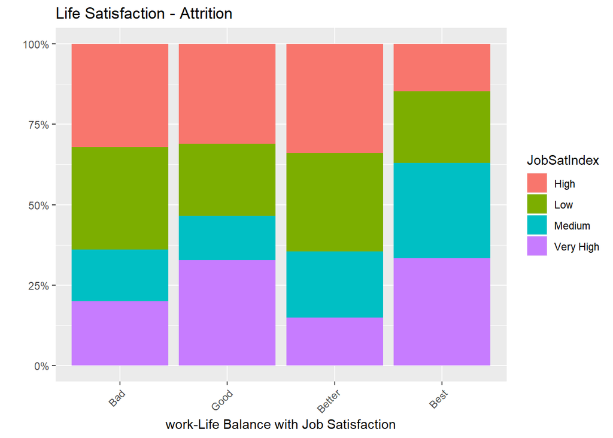

```r
#Create a visual to display.
ggplot(Satisfaction, aes(x = WorkLifeFit, fill = JobSatIndex)) + geom_bar(position = "fill") + labs(title = "Life Satisfaction - Attrition", x = "work-Life Balance with Job Satisfaction", y = "", color = "")+ scale_y_continuous(labels = scales::percent) + theme(axis.text.x = element_text(angle = 45, hjust = 1)) + scale_x_discrete(limits=c("Bad","Good","Better","Best"))
```

```r
#Create a Life Satisfaction data frame with Attrition (No), Work Life Balance and Job Satsifaction.
SatisfactionN <- subset(df, Attrition=="No", select=c(JobSatIndex, WorkLifeFit, Attrition))
head(SatisfactionN)
```

```
## # A tibble: 6 x 3
##   JobSatIndex WorkLifeFit Attrition
##   <chr>       <chr>       <chr>
## 1 Medium      Better      No
## 2 High        Better      No
## 3 Medium      Better      No
## 4 Very High   Good        No
## 5 Low         Good        No
## 6 High        Better      No
```

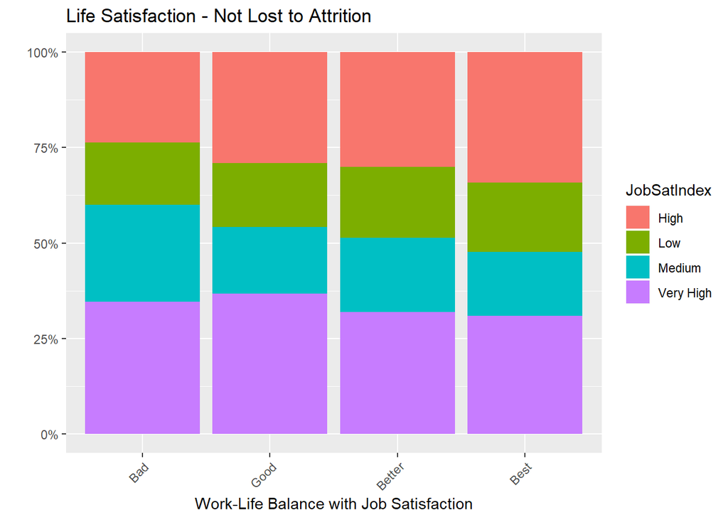

```r
#Create a visual to display.
ggplot(SatisfactionN, aes(x = WorkLifeFit, fill = JobSatIndex)) + geom_bar(position = "fill") + labs(title = "Life Satisfaction - Not Lost to Attrition", x = "Work-Life Balance with Job Satisfaction", y = "", color = "")+ scale_y_continuous(labels = scales::percent) + theme(axis.text.x = element_text(angle = 45, hjust = 1)) + scale_x_discrete(limits=c("Bad","Good","Better","Best"))
```

# EDA for Case Study 2

# Analysis of Other Possible Attrition Factors

### Field of Study

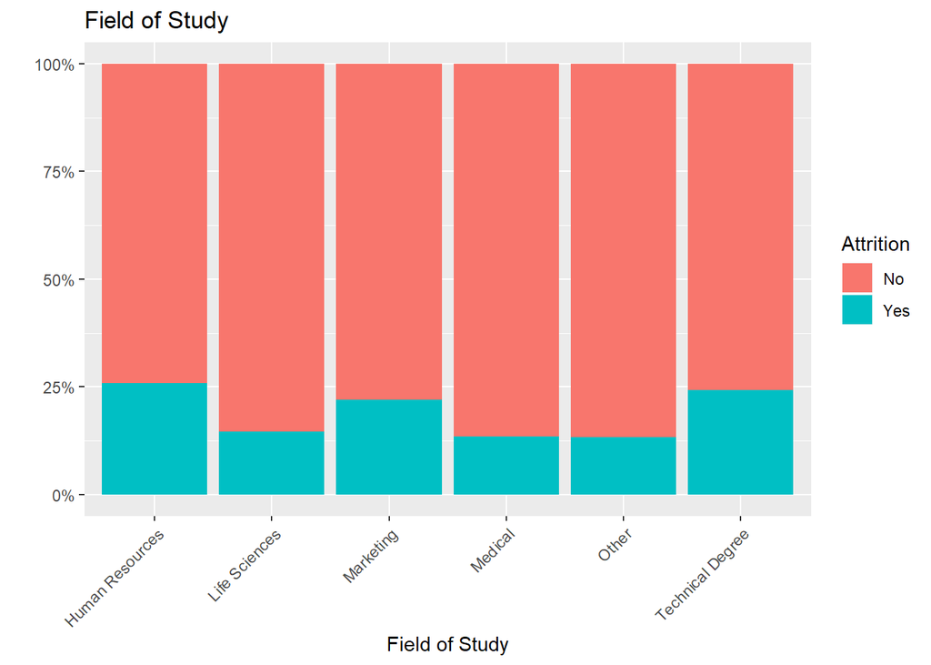

```r
#Field of Study
ggplot(df, aes(x = FieldOfStudy, fill = Attrition)) + geom_bar(position = "fill") + labs(title = "Field of Study", x = "Field of Study", y = "", color = "")+ scale_y_continuous(labels = scales::percent) + theme(axis.text.x = element_text(angle = 45, hjust = 1))
```

#### All fields of study have approximatley the same Attrition rate. Employees who workin the Life Sciences, Medical Field, and Other fields tend to stay longer than those in Human Resources, Marketing, and those with Technical Degrees.

### Highest Level of Education

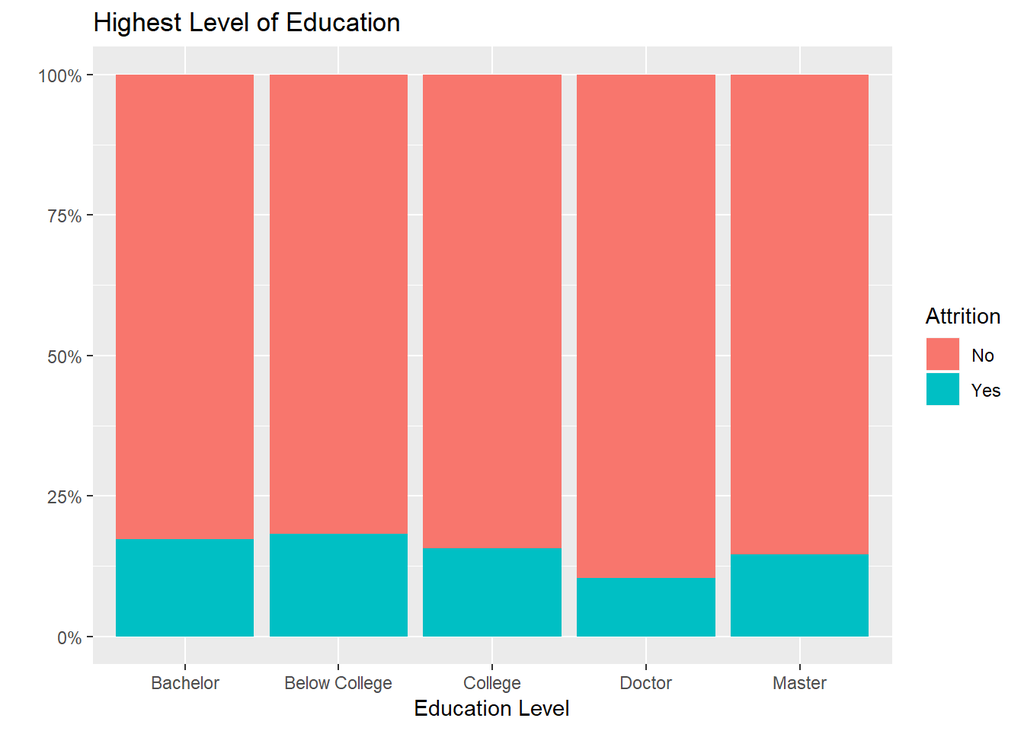

```r
#Highest Level of Education
ggplot(df, aes(x = Education, fill = Attrition)) + geom_bar(position = "fill") + labs(title = "Highest Level of Education", x = "Education Level", y = "", color = "")+ scale_y_continuous(labels = scales::percent)
```

#### All levels of education have very similar attrition rates.

### Number of Trainings Last Year

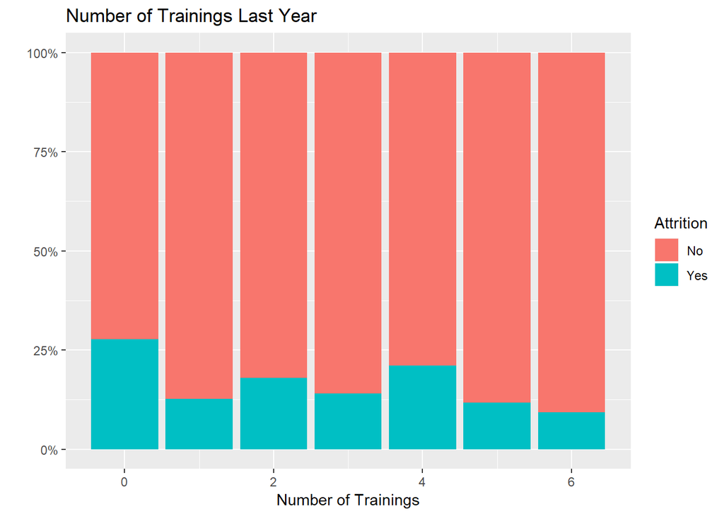

```r
#Number of Trainings Last Year
ggplot(df, aes(x = TrainedLstYr, fill = Attrition)) + geom_bar(position = "fill") + labs(title = "Number of Trainings Last Year", x = "Number of Trainings", y = "", color = "")+ scale_y_continuous(labels = scales::percent)
```

### Total Working Years

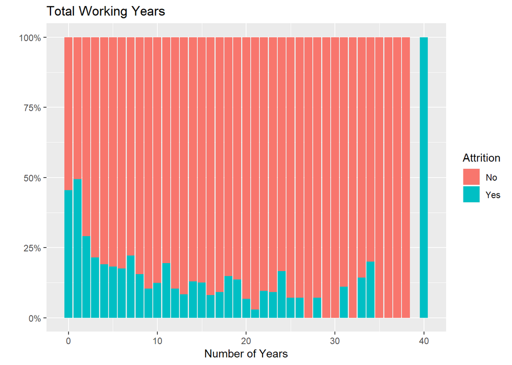

```r
#Total Working Years
ggplot(df, aes(x = TotWorkExp, fill = Attrition)) + geom_bar(position = "fill") + labs(title = "Total Working Years", x = "Number of Years", y = "", color = "")+ scale_y_continuous(labels = scales::percent)
```

#### Just over half of workers in their first two years of working stay in their jobs. The rate of attrition drops significantly after year 2 and gradually goes in a downward motion until roughly 20 years. There is some signficant differences at year 27, 29, 30, 35, 36, 37, and 38, where all workers report to have stayed in their jobs. The 100% attrition rate at year 40 could be attributed to the low number of respondants for this number of working years and/or retirement.

### Years at Current Company

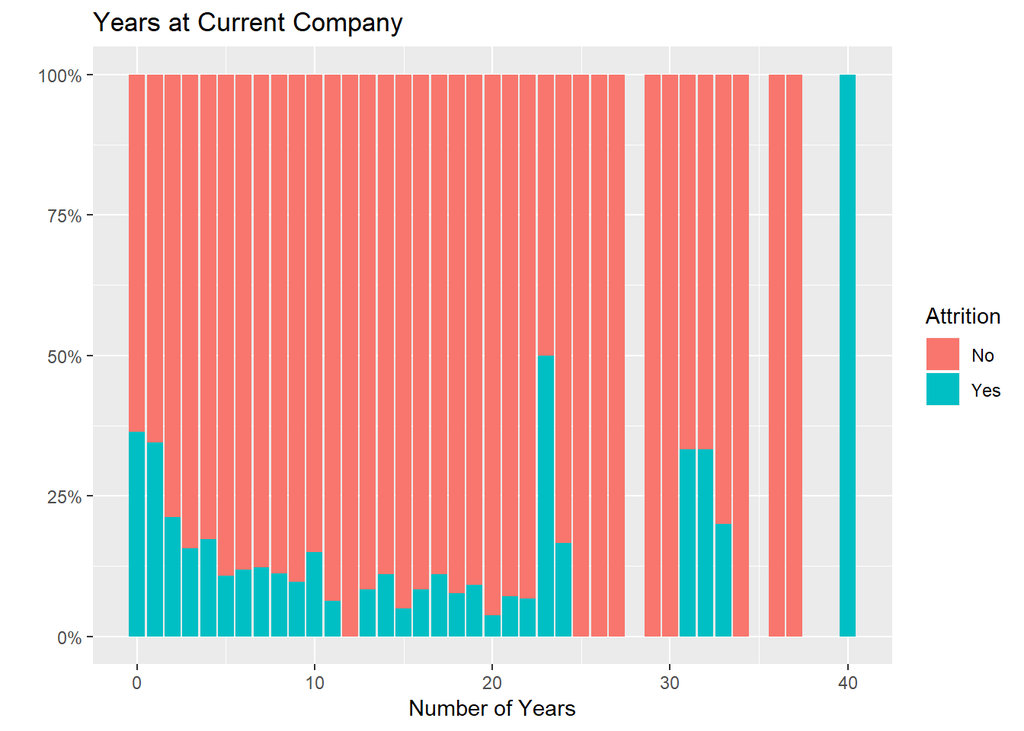

```r
#Years at Current Company
ggplot(df, aes(x = YrsAtCompany, fill = Attrition)) + geom_bar(position = "fill") + labs(title = "Years at Current Company", x = "Number of Years", y = "", color = "")+ scale_y_continuous(labels = scales::percent)
```

#### For most of the years at a company, it reflects the fact that the longer you are at a company, the longer you will stay. The exception to this is year 23 where the rate is roughly 50%. Also years 31-33 where the attrition rate is between 20% and 35%.

### Years in Current Role

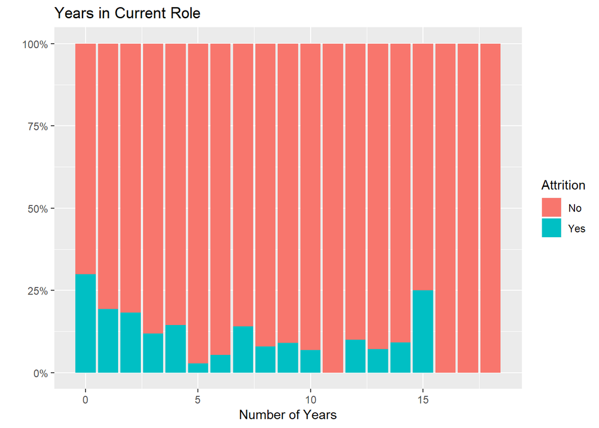

```r
#Years in Current Role
ggplot(df, aes(x = YrsInRole, fill = Attrition)) + geom_bar(position = "fill") + labs(title = "Years in Current Role", x = "Number of Years", y = "", color = "")+ scale_y_continuous(labels = scales::percent)
```

### Years Since Last Promotion

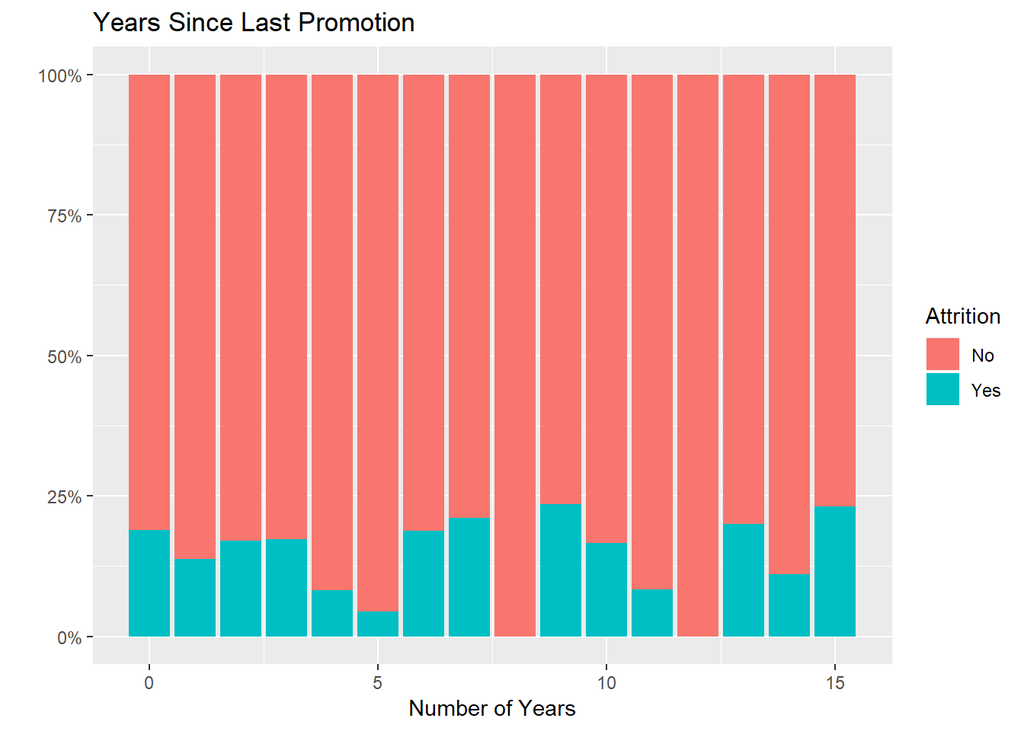

```r
#Years Since Last Promotion
ggplot(df, aes(x = LastPromoted, fill = Attrition)) + geom_bar(position = "fill") + labs(title = "Years Since Last Promotion", x = "Number of Years", y = "", color = "")+ scale_y_continuous(labels = scales::percent)
```

#### Many times promotion is emphasised in HR, however, given the data provided, the number of years since last promotion are roughly similar across the board.

### Years with Current Manager

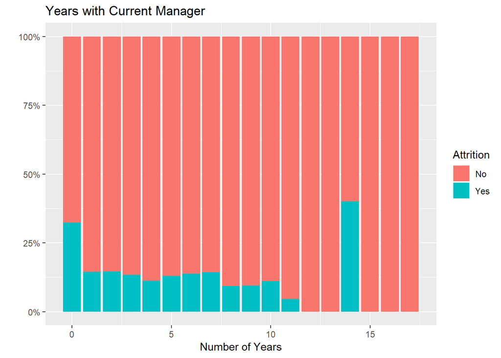

```r
#Years with Current Manager
ggplot(df, aes(x = YrsWithMgr, fill = Attrition)) + geom_bar(position = "fill") + labs(title = "Years with Current Manager", x = "Number of Years", y = "", color = "")+ scale_y_continuous(labels = scales::percent)
```